# Análisis de Datos I Tarea 1

# Ejercicio 2

**Desarrolle una función R que recibe un DataFrame y dos números de columna y que retorna el nombre de las variables correspondientes a las columnas, la covarianza y la correlación entre esas dos variables.**

A continuación se muestra el código desarrollado para la creación de la función en R.

```r
escanear <- function(dataframe, columna1, columna2){
  nombre_variables <- vector(length = 2)
  nombre_variables[1] <- colnames(dataframe)[columna1]
  nombre_variables[2] <- colnames(dataframe)[columna2]
  covarianza <- cov(dataframe[, columna1], dataframe[, columna2])
  correlacion <- cor(dataframe[, columna1], dataframe[, columna2])
  return(list(nombre_variables = nombre_variables, covarianza = covarianza,
              correlación = correlacion))
}
```

Como se puede observar la función retorna una lista donde el primer elemento es un vector con los nombres de las variables correspondientes a las columnas ingresadas, el segundo elemento es la covarianza entre las dos variables y el último es la correlación de las mismas.

Una vez hecha la función se decide hacer la siguiente prueba para corroborar.

```r
prueba <- read.csv("concreto.csv")

escanear(prueba, 3, 5)
```

```
## $nombre_variables
## [1] "ceniza_volatil"      "super_plastificante"
##
## $covarianza
## [1] 144.3225
##
## $correlación
## [1] 0.3775031
```

# Ejercicio 3

**Programe la siguiente función recursiva:**

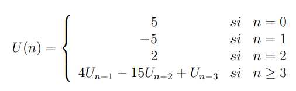

A continuación se muestra el código desarrollado para la creación de la función recursiva.

```r
U_n <- function(n){
  if(n == 0){
    resultado <- 5
  } else if(n == 1){
    resultado <- -5
  } else if(n == 2){
    resultado <- 2
  } else{
    resultado <- 4*U_n(n-1) - 15*U_n(n-2) + U_n(n-3)
  }
  return(resultado)
}
```

La función recibe un n el cual especifica el valor que se desea calcular. Con el uso de los condiconales se crean los casos posibles de cada valor. Note que cuando n es mayor o igual a tres, debido a la recursividad, el resultado vuelve a ejecutar la funión pero con los valores anteriores. Por último, la función retorna el resultado correspondiente.

Para corroborar el buen funcionamiento se decide hacer una prueba con los 11 primeros valores de la recursión.

```r
for (i in 0:10) {

  valor <- U_n(i)
  cat("U_", i, "=", valor, "\n")

}
```

```
## U_ 0 = 5
## U_ 1 = -5
## U_ 2 = 2
## U_ 3 = 88
## U_ 4 = 317
## U_ 5 = -50
## U_ 6 = -4867
## U_ 7 = -18401
## U_ 8 = -649
## U_ 9 = 268552
## U_ 10 = 1065542
```